# STAT 545 - Assignment 2

Sean La

23/09/2019

# Exercise 1

## Exercise 1.1

Let’s filter the dataset for the countries Canada, Vietnam, and China in the 1970s.

```r
dataset1.1 <- gapminder %>%
                filter(country %in% c('Canada','Vietnam','China'),year >= 1970,year < 1980)
```

## Exercise 1.2

Now we select the variables `country` and `gdpPercap`.

```r
dataset1.2 <- dataset1.1 %>% select('country','gdpPercap')
print(dataset1.2)
```

```
## # A tibble: 6 x 2
##   country gdpPercap
##   <fct>       <dbl>
## 1 Canada     18971.
## 2 Canada     22091.
## 3 China        677.
## 4 China        741.
## 5 Vietnam      700.
## 6 Vietnam      714.
```

## Exercise 1.3

Let’s add a new column containing the difference in life expectancy from the previous entry, if the previous country is of the same country.

```r
dataset1.3 <- gapminder %>%
              arrange(continent,country,year) %>%
              group_by(country) %>%
              mutate(lifeExpDiff = c(NA,diff(lifeExp))) %>%
              print()
```

```
## # A tibble: 1,704 x 7
## # Groups:   country [142]
##    country continent  year lifeExp      pop gdpPercap lifeExpDiff
##    <fct>   <fct>     <int>   <dbl>    <int>     <dbl>       <dbl>
##  1 Algeria Africa     1952    43.1  9279525     2449.       NA
##  2 Algeria Africa     1957    45.7 10270856     3014.        2.61
##  3 Algeria Africa     1962    48.3 11000948     2551.        2.62
##  4 Algeria Africa     1967    51.4 12760499     3247.        3.10
##  5 Algeria Africa     1972    54.5 14760787     4183.        3.11
##  6 Algeria Africa     1977    58.0 17152804     4910.        3.50
##  7 Algeria Africa     1982    61.4 20033753     5745.        3.35
##  8 Algeria Africa     1987    65.8 23254956     5681.        4.43
##  9 Algeria Africa     1992    67.7 26298373     5023.        1.94
## 10 Algeria Africa     1997    69.2 29072015     4797.        1.41
## # … with 1,694 more rows
```

Now, let’s filter for rows where the life expectancy difference is negative and the previous row concerns the same country.

```r
negative_life_exp_dataset <- dataset1.3 %>% filter(lifeExpDiff < 0)
print(negative_life_exp_dataset)
```

```
## # A tibble: 102 x 7
## # Groups:   country [52]
##    country            continent  year lifeExp     pop gdpPercap lifeExpDiff
##    <fct>              <fct>     <int>   <dbl>   <int>     <dbl>       <dbl>
##  1 Angola             Africa     1987    39.9  7.87e6     2430.      -0.036
##  2 Benin              Africa     2002    54.4  7.03e6     1373.      -0.371
##  3 Botswana           Africa     1992    62.7  1.34e6     7954.      -0.877
##  4 Botswana           Africa     1997    52.6  1.54e6     8647.     -10.2
##  5 Botswana           Africa     2002    46.6  1.63e6    11004.      -5.92
##  6 Burundi            Africa     1992    44.7  5.81e6      632.      -3.48
##  7 Cameroon           Africa     1992    54.3  1.25e7     1793.      -0.671
##  8 Cameroon           Africa     1997    52.2  1.42e7     1694.      -2.12
##  9 Cameroon           Africa     2002    49.9  1.59e7     1934.      -2.34
## 10 Central African R… Africa     1992    49.4  3.27e6      748.      -1.09
## # … with 92 more rows
```

## Exercise 1.4

We will find the rows corresponding to each countries’ maximum GDP per capita.

```r
max_gdpPercap <- gapminder %>% group_by(country) %>% filter(gdpPercap == max(gdpPercap))
print(max_gdpPercap)
```

```
## # A tibble: 142 x 6
## # Groups:   country [142]
##    country     continent  year lifeExp       pop gdpPercap
##    <fct>       <fct>     <int>   <dbl>     <int>     <dbl>
##  1 Afghanistan Asia       1982    39.9  12881816      978.
##  2 Albania     Europe     2007    76.4   3600523     5937.
##  3 Algeria     Africa     2007    72.3  33333216     6223.
##  4 Angola      Africa     1967    36.0   5247469     5523.
##  5 Argentina   Americas   2007    75.3  40301927    12779.
##  6 Australia   Oceania    2007    81.2  20434176    34435.
##  7 Austria     Europe     2007    79.8   8199783    36126.
##  8 Bahrain     Asia       2007    75.6    708573    29796.
##  9 Bangladesh  Asia       2007    64.1 150448339     1391.
## 10 Belgium     Europe     2007    79.4  10392226    33693.
## # … with 132 more rows
```

## Exercise 1.5

Let’s make this plot!

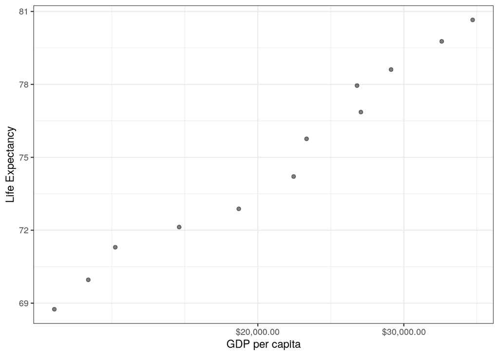

```r
gapminder %>%
  filter(country == 'Canada') %>%
  ggplot(aes(gdpPercap,lifeExp)) +
    geom_point(alpha=0.5) +
    scale_x_log10("GDP per capita", labels = scales::dollar_format()) +
    theme_bw() +
    ylab("Life Expectancy")
```

# Exercise 2

Let’s explore the relationship between continent and change in GDP per capita across years.

First, let’s make a new column `gdpPercapChange` in the `gapminder` dataset, which will be the change in GDP per capita from the previous entry/year, for only those rows where the previous row is of the same country. Otherwise, if the previous row describes a different country, we’ll just set `gdpPercapChange` to be `NA`.

```r
dataset2 <- gapminder %>%
  arrange(continent,country,year) %>%
  group_by(country) %>%
  mutate(gdpPercapChange = c(NA,diff(gdpPercap))) %>% ungroup()
```

Let’s make a quick summary of change in GDP per capita vs continent using `dplyr`, where we’ll look at the minimum, maximum, and range of change of GDP per capita within each continent.

```r
dataset2 %>%
  group_by(continent) %>%
  summarize(min_gdpPercapChange = min(gdpPercapChange,na.rm=TRUE),
                                      max_gdpPercapChange = max(gdpPercapChange,na.rm=TRUE),
                                      range_gdpPercapChange = max(gdpPercapChange,na.rm=TRUE) -
                                                              min(gdpPercapChange,na.rm=TRUE),
                                      mean_gdpPercapChange = mean(gdpPercapChange,na.rm=TRUE),
                                      sd_gdpPercapChange = sd(gdpPercapChange,na.rm=TRUE)) %>%
  DT::datatable()
```

|  | continent | min_gdpPercapChange | max_gdpPercapChange | range_gdpPercapChange | mean_gdpPercapChange | sd_gdpPercapChange |
| --- | --- | --- | --- | --- | --- | --- |
| 1 | Africa | -6632.21134 | 12015.720874 | 18647.932214 | 166.95092171958 | 964.370949689188 |
| 2 | Americas | -2169.641234 | 6547.90901 | 8717.550244 | 629.451733923636 | 1133.63896280767 |
| 3 | Asia | -50082.38986 | 28452.98374 | 78535.3736 | 661.59480600854 | 4189.93490761726 |
| 4 | Europe | -6545.810272 | 9555.10226 | 16100.912532 | 1763.03856374303 | 1677.71579998185 |
| 5 | Oceania | -643.86635 | 3747.61271 | 4391.47906 | 1773.82751136364 | 1067.22019095108 |

Interesting! It seems that countries in Africa and Asia, which mostly consist of developing countries, have the greatest rates of change in GDP per capita, as compared to the Americas and Europe. Africa and Asia also have the greatest decrease in GDP per capita, and range of the change in GDP per capita as well. While Europe and Oceania’s change in GDP fall within a relatively modest range as compared to Africa and Asia, their mean change in GDP per capita is greater than Africa and Asia’s.

Now, let’s make some boxplots to visualize the distributions of change in GDP per capita for each continent.

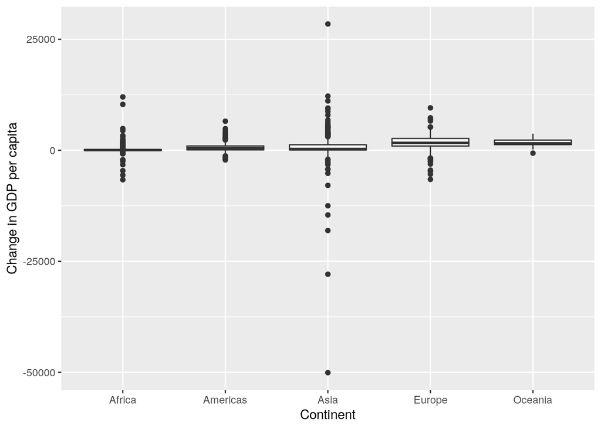

```r
dataset2 %>%
  ggplot(aes(continent,gdpPercapChange)) +
    geom_boxplot() +
    xlab('Continent') +
    ylab('Change in GDP per capita')
```

```r
dataset2 %>% filter(gdpPercapChange == min(gdpPercapChange,na.rm=TRUE)) %>% print()
```

```
## # A tibble: 1 x 7
##   country continent  year lifeExp     pop gdpPercap gdpPercapChange
##   <fct>   <fct>     <int>   <dbl>   <int>     <dbl>           <dbl>
## 1 Kuwait  Asia       1977    69.3 1140357    59265.         -50082.
```

It’s Kuwait! Fascinating.

# Exercise 3

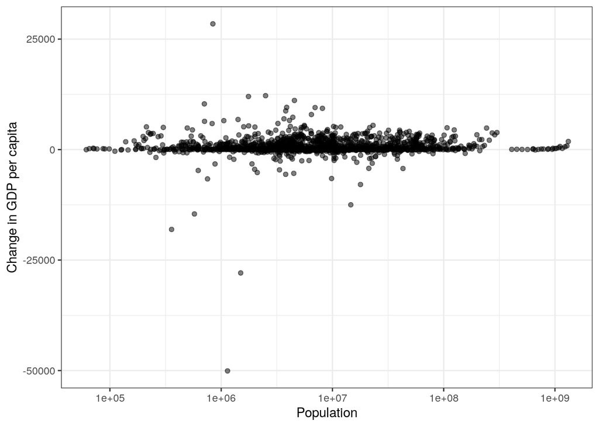

```r
dataset2 %>%
  ggplot(aes(pop,gdpPercapChange)) +
  geom_point(alpha=0.5) +
  scale_x_log10() +
  theme_bw() +
  xlab("Population") +
  ylab("Change in GDP per capita")
```

There doesn’t seem to be a relationship. Oh well!

I’m still interested in Europe’s change in GDP per capita. I wonder if it follows a normal distribution? Let’s make a histogram!

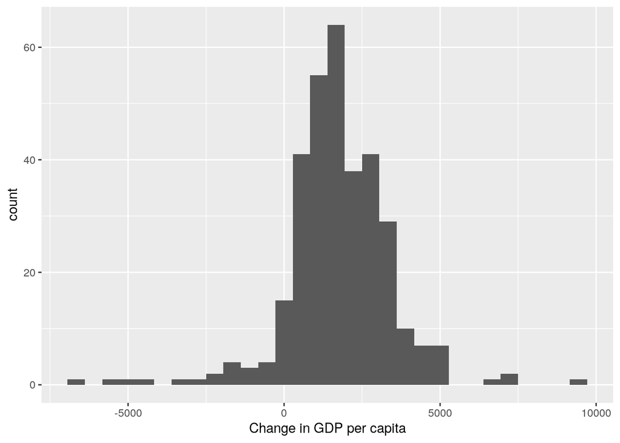

```r
dataset2 %>% filter(continent == 'Europe') %>%
  ggplot(aes(gdpPercapChange)) +
  geom_histogram() +
  xlab('Change in GDP per capita')
```

Ah, I’d say it’s roughly normal.

# Recycling (Optional)

The line of code is given as

```
filter(gapminder, country == c("Rwanda", "Afghanistan"))
```

```
filter(gapminder, country %in% c("Rwanda", "Afghanistan"))
```